# titanic regression

Data Analysis Project of a Titanic Data set

1. Import libraries and setting the enviroment
2. Load the data
3. Initial data inspection
4. Data cleaning -Null values -Handling Duplicates
5. Exploratory Data Analysis (EDA) & Visualization
6. Analyzing Relationships
7. Statiscial Analysis
8. Regression Analysis
9. Save and store work ....
10. Logistic regression
1. Import libraries and setting the enviroment

```python
import pandas as pd
import numpy as np
import matplotlib.pyplot as plt
import seaborn as sns

import warnings
warnings.filterwarnings("ignore")

# Set a style for the plots
plt.style.use('Solarize_Light2')
```

2. Load the data

```python
df = pd.read_csv('/Users/angelodaveigaalves/Downloads/train.csv')

df.head()
```

|  | PassengerId | Survived | Pclass | Name | Sex | Age | SibSp | Parch | Ticket | Fare | Cabin | Embarked |
| --- | --- | --- | --- | --- | --- | --- | --- | --- | --- | --- | --- | --- |
| 0 | 1 | 0 | 3 | Braund, Mr. Owen Harris | male | 22.0 | 1 | 0 | A/5 21171 | 7.2500 | NaN | S |
| 1 | 2 | 1 | 1 | Cumings, Mrs. John Bradley (Florence Briggs Th... | female | 38.0 | 1 | 0 | PC 17599 | 71.2833 | C85 | C |
| 2 | 3 | 1 | 3 | Heikkinen, Miss. Laina | female | 26.0 | 0 | 0 | STON/O2. 3101282 | 7.9250 | NaN | S |
| 3 | 4 | 1 | 1 | Futrelle, Mrs. Jacques Heath (Lily May Peel) | female | 35.0 | 1 | 0 | 113803 | 53.1000 | C123 | S |
| 4 | 5 | 0 | 3 | Allen, Mr. William Henry | male | 35.0 | 0 | 0 | 373450 | 8.0500 | NaN | S |

3. Initial data inspection

```python
df.shape
```

```
(891, 12)
```

```python
df.info()
```

```
<class 'pandas.core.frame.DataFrame'>
RangeIndex: 891 entries, 0 to 890
Data columns (total 12 columns):
 #   Column       Non-Null Count  Dtype
---  ------       --------------  -----
 0   PassengerId  891 non-null    int64
 1   Survived     891 non-null    int64
 2   Pclass       891 non-null    int64
 3   Name         891 non-null    object
 4   Sex          891 non-null    object
 5   Age          714 non-null    float64
 6   SibSp        891 non-null    int64
 7   Parch        891 non-null    int64
 8   Ticket       891 non-null    object
 9   Fare         891 non-null    float64
 10  Cabin        204 non-null    object
 11  Embarked     889 non-null    object
dtypes: float64(2), int64(5), object(5)
memory usage: 83.7+ KB
```

4. Data cleaning -Null values

```python
df.isnull().sum()
```

```
PassengerId      0
Survived         0
Pclass           0
Name             0
Sex              0
Age            177
SibSp            0
Parch            0
Ticket           0
Fare             0
Cabin          687
Embarked         2
dtype: int64
```

```python
df = df.drop(columns =['Cabin'])

df['Age'].fillna(df['Age'].median(), inplace = True)

df['Embarked'].fillna(df['Embarked'].mode()[0], inplace = True)

df.dropna()

df.isnull().sum()
```

```
PassengerId    0
Survived       0
Pclass         0
Name           0
Sex            0
Age            0
SibSp          0
Parch          0
Ticket         0
Fare           0
Embarked       0
dtype: int64
```

```
- handling Duplicates
```

```python
df.duplicated().sum()

df.drop_duplicates()
```

|  | PassengerId | Survived | Pclass | Name | Sex | Age | SibSp | Parch | Ticket | Fare | Embarked |
| --- | --- | --- | --- | --- | --- | --- | --- | --- | --- | --- | --- |
| 0 | 1 | 0 | 3 | Braund, Mr. Owen Harris | male | 22.0 | 1 | 0 | A/5 21171 | 7.2500 | S |
| 1 | 2 | 1 | 1 | Cumings, Mrs. John Bradley (Florence Briggs Th... | female | 38.0 | 1 | 0 | PC 17599 | 71.2833 | C |
| 2 | 3 | 1 | 3 | Heikkinen, Miss. Laina | female | 26.0 | 0 | 0 | STON/O2. 3101282 | 7.9250 | S |
| 3 | 4 | 1 | 1 | Futrelle, Mrs. Jacques Heath (Lily May Peel) | female | 35.0 | 1 | 0 | 113803 | 53.1000 | S |
| 4 | 5 | 0 | 3 | Allen, Mr. William Henry | male | 35.0 | 0 | 0 | 373450 | 8.0500 | S |
| ... | ... | ... | ... | ... | ... | ... | ... | ... | ... | ... | ... |
| 886 | 887 | 0 | 2 | Montvila, Rev. Juozas | male | 27.0 | 0 | 0 | 211536 | 13.0000 | S |
| 887 | 888 | 1 | 1 | Graham, Miss. Margaret Edith | female | 19.0 | 0 | 0 | 112053 | 30.0000 | S |
| 888 | 889 | 0 | 3 | Johnston, Miss. Catherine Helen "Carrie" | female | 28.0 | 1 | 2 | W./C. 6607 | 23.4500 | S |
| 889 | 890 | 1 | 1 | Behr, Mr. Karl Howell | male | 26.0 | 0 | 0 | 111369 | 30.0000 | C |
| 890 | 891 | 0 | 3 | Dooley, Mr. Patrick | male | 32.0 | 0 | 0 | 370376 | 7.7500 | Q |

891 rows × 11 columns

```python
df.duplicated().sum()
```

```
0
```

5. Exploratory Data Analysis (EDA) & Visualization

```python
df.describe().round(2)
```

|  | PassengerId | Survived | Pclass | Age | SibSp | Parch | Fare |
| --- | --- | --- | --- | --- | --- | --- | --- |
| count | 891.00 | 891.00 | 891.00 | 891.00 | 891.00 | 891.00 | 891.00 |
| mean | 446.00 | 0.38 | 2.31 | 29.36 | 0.52 | 0.38 | 32.20 |
| std | 257.35 | 0.49 | 0.84 | 13.02 | 1.10 | 0.81 | 49.69 |
| min | 1.00 | 0.00 | 1.00 | 0.42 | 0.00 | 0.00 | 0.00 |
| 25% | 223.50 | 0.00 | 2.00 | 22.00 | 0.00 | 0.00 | 7.91 |
| 50% | 446.00 | 0.00 | 3.00 | 28.00 | 0.00 | 0.00 | 14.45 |
| 75% | 668.50 | 1.00 | 3.00 | 35.00 | 1.00 | 0.00 | 31.00 |
| max | 891.00 | 1.00 | 3.00 | 80.00 | 8.00 | 6.00 | 512.33 |

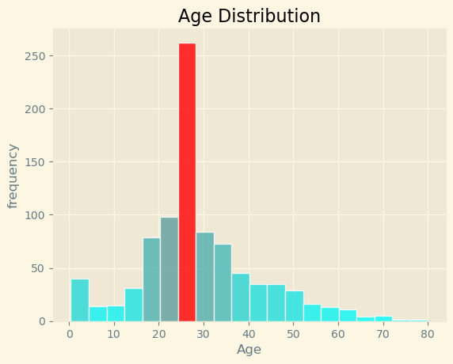

```python
from matplotlib.colors import LinearSegmentedColormap

n, bins, patches = plt.hist(df['Age'], bins=20, edgecolor='white', alpha= 0.8)
plt.title('Age Distribution', color='Black')
plt.xlabel('Age')
plt.ylabel('frequency')


cmap = LinearSegmentedColormap.from_list('shades_of_cyan', ['cyan','red'])
norm = plt.Normalize(vmin=n.min(), vmax=n.max())

for bin_value, patch in zip(n, patches):
    color = cmap(norm(bin_value))
    patch.set_facecolor(color)
```

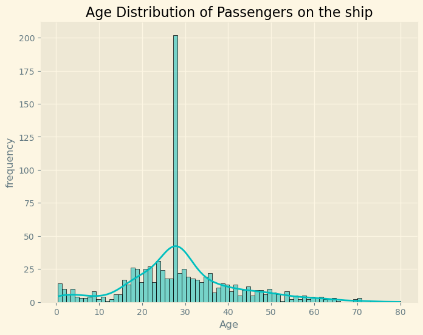

```python
#dist. of age among the passengers
plt.figure(figsize = (8,6))
sns.histplot(df['Age'], kde= True, color= 'c', bins=80)
plt.title('Age Distribution of Passengers on the ship', color='Black')
plt.xlabel('Age')
plt.ylabel('frequency')
plt.show()
```

```python
age_mode = df['Age'].mode()

print(f"The most commun age value of the passengers is {int(age_mode) } years")
```

```
The most commun age value of the passengers is 28 years
```

```python
age_mean = df['Age'].mean().round(0)
print(f"The average age of the passengers is {int(age_mean) } years")
```

```
The average age of the passengers is 29 years
```

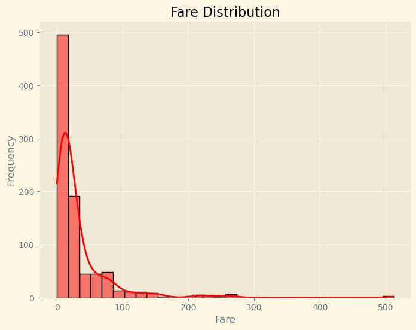

```python
#fare dist.
plt.figure(figsize=(8, 6))
sns.histplot(df['Fare'], kde= True, color='r', bins=30 )
plt.title('Fare Distribution', color='Black')
plt.xlabel('Fare')
plt.ylabel('Frequency')
plt.show()
```

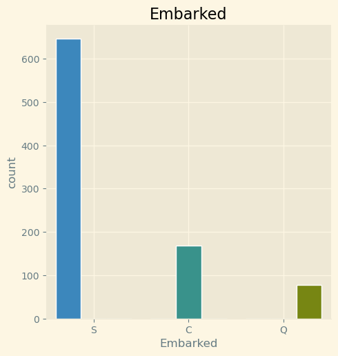

```python
#count of passengers grouped by where they embarked
plt.figure(figsize=(8,6))
sns.catplot(x='Embarked', data = df, kind='count', hue ='Embarked', edgecolor='white')
plt.title('Embarked', color='Black')
plt.xlabel('Embarked')
plt.ylabel('count')
plt.grid(True)
plt.show()
```

S stands for Southampton.

C stands for Cherbourg.

Q stands for Queenstown.

```python
#count of passengers grouped by where they embarked
s_count = df['Embarked'].value_counts().get('S', 0)
c_count = df['Embarked'].value_counts().get('C', 0)
q_count = df['Embarked'].value_counts().get('Q', 0)

print(f"Number of passengers who embarked at Southampton (S): {s_count}")
print(f"Number of passengers who embarked at Cherbourg   (C): {c_count}")
print(f"Number of passengers who embarked at Queenstown  (Q): {q_count}")
```

```
Number of passengers who embarked at Southampton (S): 646
Number of passengers who embarked at Cherbourg   (C): 168
Number of passengers who embarked at Queenstown  (Q): 77
```

6. Analyzing Relationships

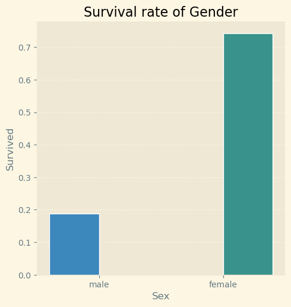

```python
#survival rate of gender
plt.figure(figsize=(8,6))
sns.catplot(x='Sex', y='Survived', data=df, kind='bar', hue='Sex', ci = None, edgecolor='white')
plt.title('Survival rate of Gender', color='Black')
plt.grid(axis='y', linestyle= '--', alpha= 0.7 )
plt.show()
```

```python
#total percentage of survived passengers
number_of_passengers = df['Name'].value_counts().sum()
number_of_passengers_survived = survived_male_count + survived_female_count
percentage_survived = (number_of_passengers_survived/number_of_passengers)* 100
```

[output not shown]

```python
#number of count and percentage of survived passengersm grouped by sex


survived_female_count = survived_df['Sex'].value_counts().get('female', 0)
survived_male_count = survived_df['Sex'].value_counts().get('male', 0)

total_sex_countf = df['Sex'].value_counts().get('female', 0)
total_sex_countm = df['Sex'].value_counts().get('male', 0)

percentage_female_survived = (survived_female_count/ total_sex_countf )* 100
percentage_male_survived = (survived_male_count/total_sex_countm )* 100

percentage_delta =  percentage_female_survived- percentage_male_survived

print(f"The number of survived female passengers is {survived_female_count } and the number of surviving male passengers is {survived_male_count}, so {percentage_delta.round(2)} % more female passengers survived than male passengers.")
print(f"It only survived {percentage_survived.round(2)} % of all the people on board.")
```

[output not shown]

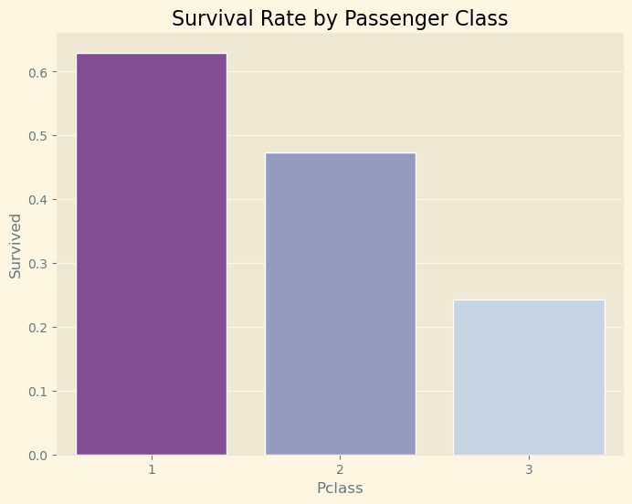

```python
# survival rate grouped by passenger class
plt.figure(figsize=(8, 6))
sns.barplot(x='Pclass', y='Survived', data=df, palette='BuPu_r', ci =None, edgecolor='white')
plt.title('Survival Rate by Passenger Class', color ='Black')
plt.show()
```

7. Statiscial Analysis

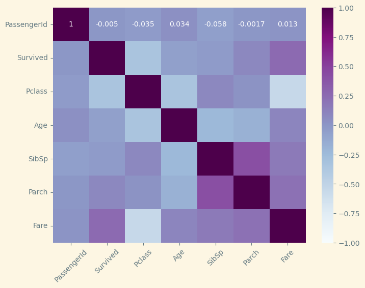

```python
#correlation analysis
correlation = df.corr()

plt.figure(figsize=(8,6))
plt.xticks(rotation=45)
sns.heatmap(correlation, annot= True, cmap='BuPu', vmin=-1, vmax=1)
```

There is a strong negative correlation between the Fare price and the Passenger Class, which is just misleading, since the upper class are notated with numerical values as 1, as first class. Obviously the first class tickets are more expensive than a lower passenger class such as 2 and 3.

There is also a strong positive correlation between the number of siblings and spouse, in the SibSp column and the Parch column which stands for the number of parents or guardians present. There was a higher number of Parch as the number of SibSp increases.

```python
#print(plt.colormaps)
```

```python
#Average Age of Passengers by Survival Status
age_mean= df.groupby('Survived')['Age'].mean()
age_mean.round(2)
```

```
Survived
0    30.03
1    28.29
Name: Age, dtype: float64
```

```
 [Text(0, 0, 'Not Survived'), Text(1, 0, 'Survived')])
```

[figure not shown]

```python
#Average Age of Passengers by Survival Status
plt.figure(figsize=(8, 6))
age_mean.plot(kind='bar', color=['purple','violet'], alpha=0.5)


plt.title('Average Age of Passengers by Survival Status', color='Black')
plt.xlabel('Survived')
plt.ylabel('Average Age')
plt.xticks(ticks=[0, 1], labels=['Not Survived', 'Survived'], rotation=0)
```

```python
#Average Fare of Passengers by Survival Status
mean_fare = df.groupby('Survived')['Fare'].mean()

mean_fare.round(2)
```

```
Survived
0    22.12
1    48.40
Name: Fare, dtype: float64
```

```
 [Text(0, 0, 'Not Survived'), Text(1, 0, 'Survived')])
```

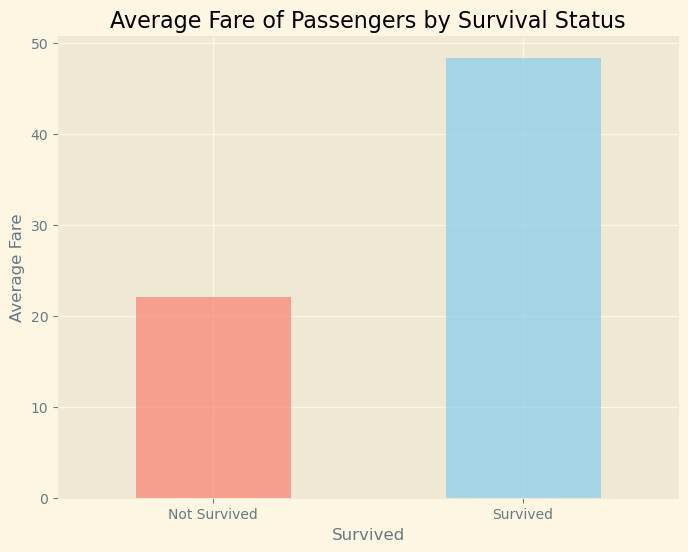

```python
plt.figure(figsize=(8, 6))
mean_fare.plot(kind='bar', color=['salmon','skyblue'], alpha=0.7)

plt.title('Average Fare of Passengers by Survival Status', color= 'Black')
plt.xlabel('Survived')
plt.ylabel('Average Fare')
plt.xticks(ticks=[0, 1], labels=['Not Survived', 'Survived'], rotation=0)
```

7. Probability and Distributions

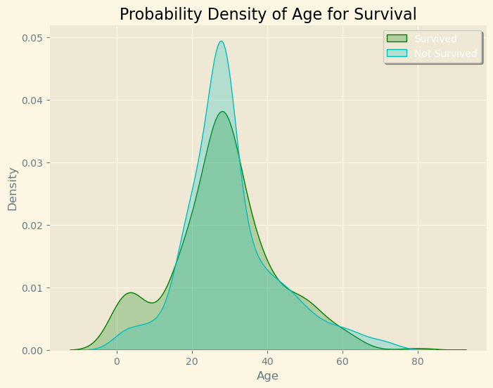

```python
#Probability Density of Age for Survival
plt.figure(figsize=(8,6))
sns.kdeplot(df[df['Survived'] ==1]['Age'], color='green', label='Survived', shade=True)
sns.kdeplot(df[df['Survived'] == 0]['Age'], color = 'c',label= 'Not Survived', shade=True)
plt.title('Probability Density of Age for Survival', color='Black')
plt.xlabel('Age')
plt.ylabel('Density')
plt.legend(shadow=True)
plt.show()
```

8. Regression Analysis

simple linear regression to predict Fare based on Age:

[figure not shown]

```python
#regression analysis
#which code shoul i use, first or second ?
from sklearn.linear_model import LinearRegression

X = df[['Age']]
y = df['Fare']

model = LinearRegression()
model.fit(X, y)

predictions = model.predict(X)

plt.figure(figsize=(8, 6))
plt.scatter(df['Age'], df['Fare'], color='maroon', label='Actual Data', edgecolors='white')
plt.plot(df['Age'], predictions, color='c', label='regression line')
plt.title('Fare vs Age Regression', color='Black')
plt.xlabel('Age')
plt.ylabel('Fare')
plt.legend()
plt.show()
```

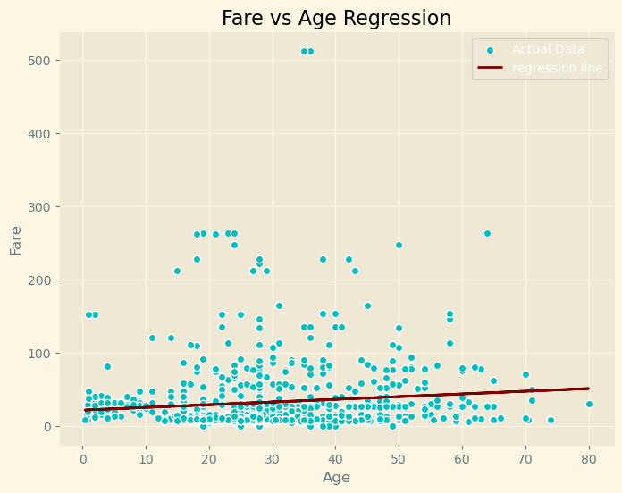

```python
from scipy import stats

X = df['Age']
y = df['Fare']


slope, intercept, r_value, p_value, std_err = stats.linregress(X, y)


predictions1 = slope * X + intercept

plt.figure(figsize=(8, 6))
plt.scatter(df['Age'], df['Fare'], color='c', label='Actual Data', edgecolors='white')
plt.plot(df['Age'], predictions1, color='maroon', label='regression line')
plt.title('Fare vs Age Regression', color='Black')
plt.xlabel('Age')
plt.ylabel('Fare')
plt.legend()
plt.show()
```

```
Key Findings:
- Age and Fare have a weak positive correlation.
- Higher-class passengers had higher survival rates.
- Women had a significantly higher survival rate compared to men.
```

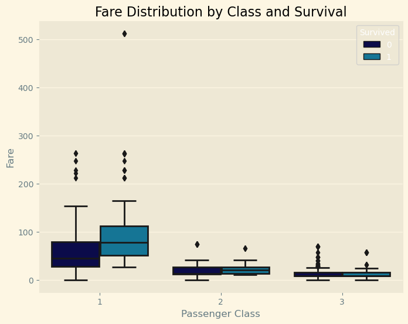

```python
# Summarize key findings
print("Key Findings:")
print("- Age and Fare have a weak positive correlation.")
print("- Higher-class passengers had higher survival rates.")
print("- Women had a significantly higher survival rate compared to men.")

plt.figure(figsize=(8,6))
sns.boxplot(x='Pclass', y='Fare', hue='Survived', data=df, palette='ocean')
plt.title('Fare Distribution by Class and Survival', color='Black')
plt.xlabel('Passenger Class')
plt.ylabel('Fare')
plt.show()
```

9. Save and store work ....

```python
#df.to_csv('cleaned_titanic.csv', index=False)
```

10. Logistic regression

```
Accuracy: 0.6655443322109988
Confusion Matrix:
[[511  38]
 [260  82]]
Coefficient: 0.015196662048546118
High probability of survial :
         Fare  Predicted_Probability
258  512.3292               0.998936
737  512.3292               0.998936
679  512.3292               0.998936
88   263.0000               0.955015
27   263.0000               0.955015
341  263.0000               0.955015
438  263.0000               0.955015
311  262.3750               0.954605
742  262.3750               0.954605
118  247.5208               0.943756
Low probability of survival :
       Fare  Predicted_Probability
378  4.0125               0.293107
872  5.0000               0.296226
326  6.2375               0.300162
843  6.4375               0.300800
818  6.4500               0.300840
371  6.4958               0.300987
202  6.4958               0.300987
654  6.7500               0.301800
143  6.7500               0.301800
411  6.8583               0.302147
```

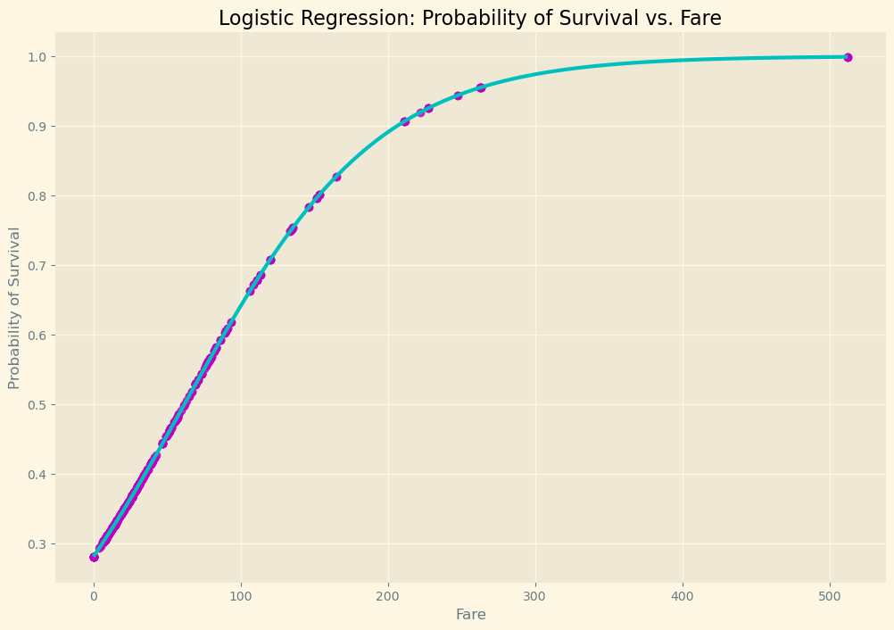

```python
from sklearn.linear_model import LogisticRegression
from sklearn.metrics import accuracy_score, confusion_matrix, classification_report, roc_curve, auc


#Data

x = df[['Fare']]
y = df['Survived']

#Model

mod = LogisticRegression()
mod.fit(x, y)
fare_pred = mod.predict(x)

#Metrics

accuracy = accuracy_score(y, fare_pred)
conf_matrix = confusion_matrix(y, fare_pred)
#class_report = classification_report(y, fare_pred)
df['Predicted_Probability'] = mod.predict_proba(x)[:, 1]
coef= mod.coef_[0][0]

#Print

print(f'Accuracy: {accuracy}')
print(f'Confusion Matrix:')
print(conf_matrix)
#print(class_report)
#print(df['Predicted_Probability'][: -1])
print(f'Coefficient: {coef}')

proba_table_high_p = df[['Fare', 'Predicted_Probability']].sort_values( by = 'Predicted_Probability', ascending= False)
proba_table_low_p = df[df['Fare'] > 0.000][['Fare', 'Predicted_Probability']].sort_values(by='Predicted_Probability', ascending=True)

proba_table_high_p_10 = proba_table_high_p.head(10)
proba_table_low_p_10 = proba_table_low_p.head(10)

print(f'High probability of survial :')
print(proba_table_high_p_10)
print(f'Low probability of survival :')
print(proba_table_low_p_10)

#Visual

plt.figure(figsize=(12,8))
sns.regplot(x='Fare', y='Predicted_Probability', data=df, logistic=True, ci=None, scatter_kws={'color': 'm'}, line_kws={'color': 'c'})
plt.title('Logistic Regression: Probability of Survival vs. Fare')
plt.xlabel('Fare')
plt.ylabel('Probability of Survival')
plt.show()
```

Positive Coefficient: Indicates that higher fare values are associated with higher probabilities of survival. This might reflect that passengers who paid more for their tickets had better chances of survival.

Negative Coefficient: Suggests that higher fare values are associated with lower probabilities of survival, which could be counterintuitive and might indicate a need for more feature engineering or additional data.

```
ROC AUC: 0.6921223063730972
```

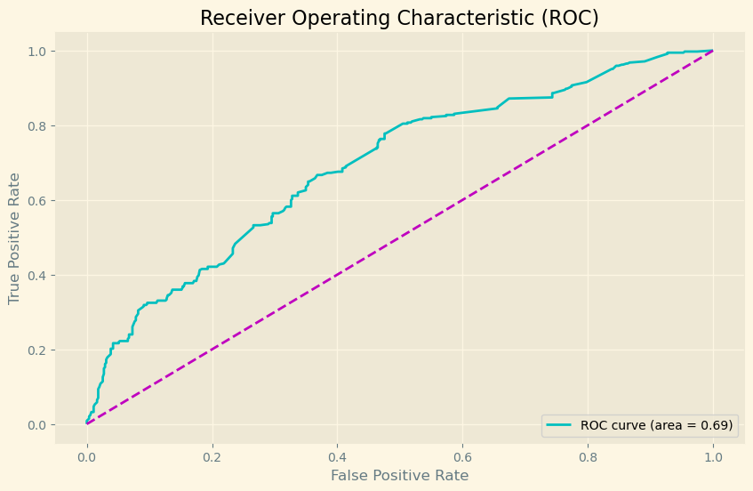

```python
fpr, tpr, thresholds = roc_curve(y, df['Predicted_Probability'])
roc_auc = auc(fpr, tpr)


print(f'ROC AUC: {roc_auc}')


plt.figure(figsize=(10, 6))
plt.plot(fpr, tpr, color='c', lw=2, label=f'ROC curve (area = {roc_auc:.2f})')
plt.plot([0, 1], [0, 1], color='m', linestyle='--')
plt.xlabel('False Positive Rate')
plt.ylabel('True Positive Rate')
plt.title('Receiver Operating Characteristic (ROC)')
plt.legend(loc='lower right')
plt.show()
```

AUC = 1.0: Perfect model. AUC = 0.5: Model performs no better than random guessing. AUC < 0.5: Model performs worse than random guessing.